# Loan Data Analysis:A Comprehensive Predictive Modeling Study

# Data Preprocessing

## Outlier Treatment

```r
cat("Before outlier treatment:", nrow(df), "rows\n\n")
```

```
## Before outlier treatment: 45000 rows
```

```r
cat("Ages > 80:", sum(df$person_age > 80), "\n")
```

```
## Ages > 80: 9
```

```r
df <- df %>% filter(person_age <= 80)

cat("Employment experience > 60:", sum(df$person_emp_exp > 60), "\n")
```

```
## Employment experience > 60: 1
```

```r
df <- df %>% filter(person_emp_exp <= 60)

income_cap <- quantile(df$person_income, 0.995)
cat("Income cap (99.5th percentile):", income_cap, "\n")
```

```
## Income cap (99.5th percentile): 360727.5
```

```r
cat("Records above cap:", sum(df$person_income > income_cap), "\n")
```

```
## Records above cap: 225
```

```r
df <- df %>% filter(person_income <= income_cap)

cat("\nAfter outlier treatment:", nrow(df), "rows\n")
```

```
##
## After outlier treatment: 44765 rows
```

## Encode Categorical Variables

```r
df <- df %>%
  mutate(
    person_gender                  = as.factor(person_gender),
    person_education               = factor(person_education,
                                            levels = c("High School", "Associate",
                                                       "Bachelor", "Master", "Doctorate"),
                                            ordered = TRUE),
    person_home_ownership          = as.factor(person_home_ownership),
    loan_intent                    = as.factor(loan_intent),
    previous_loan_defaults_on_file = as.factor(previous_loan_defaults_on_file),
    loan_status                    = as.factor(loan_status)
  )

str(df)
```

```
## tibble [44,765 × 14] (S3: tbl_df/tbl/data.frame)
##  $ person_age                    : num [1:44765] 22 21 25 23 24 21 26 24 24 21 ...
##  $ person_gender                 : Factor w/ 2 levels "female","male": 1 1 1 1 2 1 1 1 1 1 ...
##  $ person_education              : Ord.factor w/ 5 levels "High School"<..: 4 1 1 3 4 1 3 1 2 1 ...
##  $ person_income                 : num [1:44765] 71948 12282 12438 79753 66135 ...
##  $ person_emp_exp                : num [1:44765] 0 0 3 0 1 0 1 5 3 0 ...
##  $ person_home_ownership         : Factor w/ 4 levels "MORTGAGE","OTHER",..: 4 3 1 4 4 3 4 4 4 3 ...
##  $ loan_amnt                     : num [1:44765] 35000 1000 5500 35000 35000 2500 35000 35000 35000 1600 ...
##  $ loan_intent                   : Factor w/ 6 levels "DEBTCONSOLIDATION",..: 5 2 4 4 4 6 2 4 5 6 ...
##  $ loan_int_rate                 : num [1:44765] 16 11.1 12.9 15.2 14.3 ...
##  $ loan_percent_income           : num [1:44765] 0.49 0.08 0.44 0.44 0.53 0.19 0.37 0.37 0.35 0.13 ...
##  $ cb_person_cred_hist_length    : num [1:44765] 3 2 3 2 4 2 3 4 2 3 ...
##  $ credit_score                  : num [1:44765] 561 504 635 675 586 532 701 585 544 640 ...
##  $ previous_loan_defaults_on_file: Factor w/ 2 levels "No","Yes": 1 2 1 1 1 1 1 1 1 1 ...
##  $ loan_status                   : Factor w/ 2 levels "0","1": 2 1 2 2 2 2 2 2 2 2 ...
```

It converts text-based columns (like gender, education, loan intent) into R **factors**, so that modeling functions know they’re categorical variables and handle them correctly.

Education is set as an **ordered** factor (High School < Associate < Bachelor < Master < Doctorate) because its categories have a natural ranking, while the others are unordered.

# Feature Engineering

We created **domain-informed features** that capture relationships the raw variables miss.

| New Feature | Logic | Rationale |
| --- | --- | --- |
| `loan_credit_ratio` | loan_amnt and credit_score | Loan burden relative to credit worthiness |
| `age_exp_ratio` | emp_exp and age | Career progression proxy |
| `income_per_exp` | income and emp_exp | Earning efficiency |
| `credit_hist_per_age` | cred_hist_length and age | Financial maturity |
| `high_risk` | loan% > 0.3 and credit < 600 | Binary risk flag |
| `age_group` | Binned age | Life-stage segmentation |
| `income_bracket` | Quartile-based bins | Socioeconomic stratum |

```r
df$loan_credit_ratio   <- df$loan_amnt / df$credit_score
df$age_exp_ratio       <- ifelse(df$person_age > 0, df$person_emp_exp / df$person_age, 0)
df$income_per_exp      <- ifelse(df$person_emp_exp > 0,
                                 df$person_income / df$person_emp_exp,
                                 df$person_income)
df$credit_hist_per_age <- df$cb_person_cred_hist_length / df$person_age
df$high_risk           <- as.factor(
  ifelse(df$loan_percent_income > 0.3 & df$credit_score < 600, 1, 0))
df$age_group           <- cut(df$person_age,
                              breaks = c(19, 25, 35, 50, 80),
                              labels = c("Young Adult", "Adult", "Middle Age", "Senior"))
df$income_bracket      <- cut(df$person_income,
                              breaks = quantile(df$person_income, probs = c(0, .25, .5, .75, 1)),
                              labels = c("Low", "Lower-Mid", "Upper-Mid", "High"),
                              include.lowest = TRUE)
```

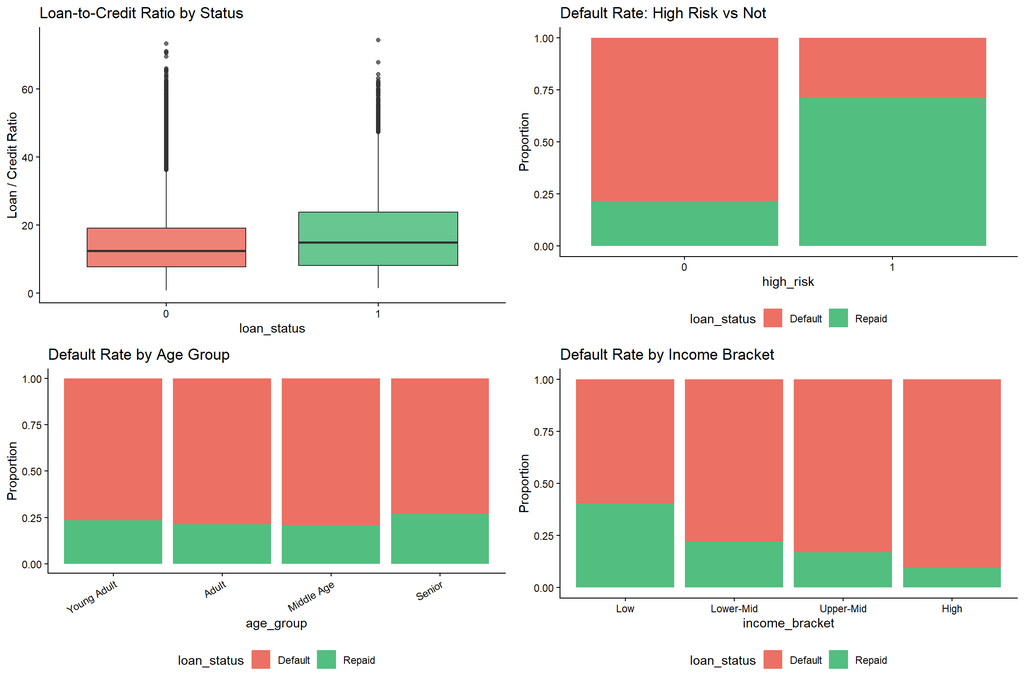

```r
p1 <- ggplot(df, aes(x = loan_status, y = loan_credit_ratio, fill = loan_status)) +
  geom_boxplot(alpha = 0.7) +
  scale_fill_manual(values = c("#e74c3c", "#27ae60")) +
  labs(title = "Loan-to-Credit Ratio by Status", y = "Loan / Credit Ratio") +
  theme(legend.position = "none")

p2 <- ggplot(df, aes(x = high_risk, fill = loan_status)) +
  geom_bar(position = "fill", alpha = 0.8) +
  scale_fill_manual(values = c("#e74c3c", "#27ae60"), labels = c("Default", "Repaid")) +
  labs(title = "Default Rate: High Risk vs Not", y = "Proportion") +
  theme(legend.position = "bottom")

p3 <- ggplot(df, aes(x = age_group, fill = loan_status)) +
  geom_bar(position = "fill", alpha = 0.8) +
  scale_fill_manual(values = c("#e74c3c", "#27ae60"), labels = c("Default", "Repaid")) +
  labs(title = "Default Rate by Age Group", y = "Proportion") +
  theme(legend.position = "bottom", axis.text.x = element_text(angle = 30, hjust = 1))

p4 <- ggplot(df, aes(x = income_bracket, fill = loan_status)) +
  geom_bar(position = "fill", alpha = 0.8) +
  scale_fill_manual(values = c("#e74c3c", "#27ae60"), labels = c("Default", "Repaid")) +
  labs(title = "Default Rate by Income Bracket", y = "Proportion") +
  theme(legend.position = "bottom")

grid.arrange(p1, p2, p3, p4, ncol = 2)
```

```r
corr_matrix <- cor(dplyr::select(df, where(is.numeric)))

corr_df <- as.data.frame(round(corr_matrix, 3))
corr_df
```

```
##                            person_age person_income person_emp_exp loan_amnt
## person_age                      1.000         0.109          0.951     0.047
## person_income                   0.109         1.000          0.098     0.400
## person_emp_exp                  0.951         0.098          1.000     0.041
## loan_amnt                       0.047         0.400          0.041     1.000
## loan_int_rate                   0.012        -0.008          0.016     0.145
## loan_percent_income            -0.034        -0.333         -0.031     0.606
## cb_person_cred_hist_length      0.878         0.090          0.839     0.039
## credit_score                    0.173         0.025          0.181     0.009
## loan_credit_ratio               0.027         0.392          0.020     0.988
## age_exp_ratio                   0.879         0.113          0.960     0.047
## income_per_exp                 -0.492         0.377         -0.561     0.166
## credit_hist_per_age             0.702         0.083          0.666     0.036
##                            loan_int_rate loan_percent_income
## person_age                         0.012              -0.034
## person_income                     -0.008              -0.333
## person_emp_exp                     0.016              -0.031
## loan_amnt                          0.145               0.606
## loan_int_rate                      1.000               0.127
## loan_percent_income                0.127               1.000
## cb_person_cred_hist_length         0.017              -0.024
## credit_score                       0.011              -0.010
## loan_credit_ratio                  0.142               0.601
## age_exp_ratio                      0.018              -0.036
## income_per_exp                    -0.026              -0.139
## credit_hist_per_age                0.019              -0.019
##                            cb_person_cred_hist_length credit_score
## person_age                                      0.878        0.173
## person_income                                   0.090        0.025
## person_emp_exp                                  0.839        0.181
## loan_amnt                                       0.039        0.009
## loan_int_rate                                   0.017        0.011
## loan_percent_income                            -0.024       -0.010
## cb_person_cred_hist_length                      1.000        0.153
## credit_score                                    0.153        1.000
## loan_credit_ratio                               0.021       -0.119
## age_exp_ratio                                   0.784        0.178
## income_per_exp                                 -0.456       -0.107
## credit_hist_per_age                             0.941        0.126
##                            loan_credit_ratio age_exp_ratio income_per_exp
```

[output cut: 10 more lines]

```
## income_per_exp                         0.178        -0.655          1.000
## credit_hist_per_age                    0.021         0.664         -0.431
##                            credit_hist_per_age
## person_age                               0.702
## person_income                            0.083
## person_emp_exp                           0.666
## loan_amnt                                0.036
## loan_int_rate                            0.019
## loan_percent_income                     -0.019
## cb_person_cred_hist_length               0.941
## credit_score                             0.126
## loan_credit_ratio                        0.021
## age_exp_ratio                            0.664
## income_per_exp                          -0.431
## credit_hist_per_age                      1.000
```

# Part A.Regression: Predicting Income

## Objective

We train three regression models on `person_income` using demographic and engineered features. **Linear regression is the primary model** its OLS assumptions are checked and transformations are applied are needed.

## Prepare Regression Data

```r
reg_df <- dplyr::select(df, -person_emp_exp, -loan_percent_income, -person_age, -income_per_exp, -loan_credit_ratio, -cb_person_cred_hist_length, -high_risk, -age_group, -income_bracket, -loan_status) %>%
  drop_na()

reg_df$person_education <- factor(reg_df$person_education, ordered = FALSE)

cat("Regression dataset:", nrow(reg_df), "rows x", ncol(reg_df), "columns\n")
```

```
## Regression dataset: 44765 rows x 11 columns
```

```r
summary(reg_df$person_income)
```

```
##    Min. 1st Qu.  Median    Mean 3rd Qu.    Max.
##    8000   47063   66968   77224   94805  360724
```

## Income Distribution and Transformation Decision

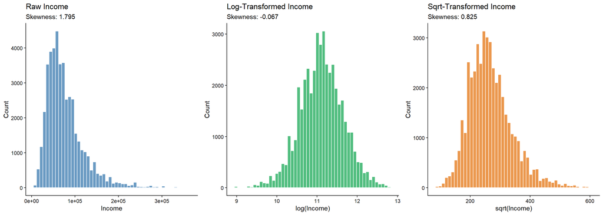

```r
p1 <- ggplot(reg_df, aes(x = person_income)) +
  geom_histogram(bins = 50, fill = "steelblue", color = "white", alpha = 0.8) +
  labs(title = "Raw Income",
       subtitle = paste("Skewness:", round(skewness(reg_df$person_income), 3)),
       x = "Income", y = "Count")

p2 <- ggplot(reg_df, aes(x = log(person_income))) +
  geom_histogram(bins = 50, fill = "#27ae60", color = "white", alpha = 0.8) +
  labs(title = "Log-Transformed Income",
       subtitle = paste("Skewness:", round(skewness(log(reg_df$person_income)), 3)),
       x = "log(Income)", y = "Count")

p3 <- ggplot(reg_df, aes(x = sqrt(person_income))) +
  geom_histogram(bins = 50, fill = "#e67e22", color = "white", alpha = 0.8) +
  labs(title = "Sqrt-Transformed Income",
       subtitle = paste("Skewness:", round(skewness(sqrt(reg_df$person_income)), 3)),
       x = "sqrt(Income)", y = "Count")

grid.arrange(p1, p2, p3, ncol = 3)
```

> **Decision:** The **log transformation** substantially reduces skewness, bringing the distribution closer to normal. We proceed with `log(person_income)` as the response.

```r
reg_df <- reg_df %>% mutate(log_income = log(person_income))
```

## TrainTest Split

```r
set.seed(42)
train_index <- createDataPartition(reg_df$log_income, p = 0.8, list = FALSE)
train_reg   <- reg_df[train_index, ]
test_reg    <- reg_df[-train_index, ]

cat("Training set:", nrow(train_reg), "rows | Test set:", nrow(test_reg), "rows\n")
```

```
## Training set: 35813 rows | Test set: 8952 rows
```

## Model 1. Linear Regression (OLS)

### Full Model

```r
lm_main <- lm(log_income ~ loan_amnt + person_home_ownership +
    loan_intent + loan_int_rate +
    person_education + person_gender, data = train_reg)
summary(lm_main)
```

```
##
## Call:
## lm(formula = log_income ~ loan_amnt + person_home_ownership +
##     loan_intent + loan_int_rate + person_education + person_gender,
##     data = train_reg)
##
## Residuals:
##      Min       1Q   Median       3Q      Max
## -1.86491 -0.29980 -0.00962  0.28889  1.85116
##
## Coefficients:
##                              Estimate Std. Error t value Pr(>|t|)
## (Intercept)                 1.108e+01  1.218e-02 909.670  < 2e-16 ***
## loan_amnt                   3.241e-05  3.916e-07  82.765  < 2e-16 ***
## person_home_ownershipOTHER -1.908e-01  4.742e-02  -4.023 5.75e-05 ***
## person_home_ownershipOWN   -3.967e-01  1.019e-02 -38.919  < 2e-16 ***
## person_home_ownershipRENT  -3.394e-01  5.129e-03 -66.183  < 2e-16 ***
## loan_intentEDUCATION       -1.405e-03  8.051e-03  -0.175   0.8614
## loan_intentHOMEIMPROVEMENT  7.173e-02  9.510e-03   7.542 4.72e-14 ***
## loan_intentMEDICAL         -4.480e-02  8.155e-03  -5.494 3.96e-08 ***
## loan_intentPERSONAL         1.200e-02  8.387e-03   1.431   0.1525
## loan_intentVENTURE          1.797e-02  8.369e-03   2.147   0.0318 *
## loan_int_rate              -7.629e-03  8.249e-04  -9.249  < 2e-16 ***
## person_educationAssociate  -9.186e-04  6.569e-03  -0.140   0.8888
## person_educationBachelor    5.726e-03  6.400e-03   0.895   0.3710
## person_educationMaster      1.376e-02  7.668e-03   1.794   0.0728 .
## person_educationDoctorate   1.201e-02  2.078e-02   0.578   0.5634
## person_gendermale           5.548e-03  4.816e-03   1.152   0.2493
## ---
## Signif. codes:  0 '***' 0.001 '**' 0.01 '*' 0.05 '.' 0.1 ' ' 1
##
## Residual standard error: 0.4532 on 35797 degrees of freedom
## Multiple R-squared:  0.2876, Adjusted R-squared:  0.2873
## F-statistic: 963.7 on 15 and 35797 DF,  p-value: < 2.2e-16
```

```r
lm_full <- lm(log_income ~ .-person_income ,data = train_reg)

summary(lm_full)
```

```
##
## Call:
## lm(formula = log_income ~ . - person_income, data = train_reg)
##
## Residuals:
##      Min       1Q   Median       3Q      Max
## -1.87214 -0.29409 -0.01394  0.28680  1.86581
##
## Coefficients:
##                                     Estimate Std. Error t value Pr(>|t|)
## (Intercept)                        1.072e+01  3.363e-02 318.749  < 2e-16 ***
## person_gendermale                  5.496e-03  4.736e-03   1.160 0.245874
## person_educationAssociate         -4.324e-03  6.481e-03  -0.667 0.504689
## person_educationBachelor           7.032e-03  6.371e-03   1.104 0.269710
## person_educationMaster             1.318e-02  7.668e-03   1.719 0.085673 .
## person_educationDoctorate         -2.094e-02  2.067e-02  -1.013 0.310962
## person_home_ownershipOTHER        -1.613e-01  4.664e-02  -3.457 0.000546 ***
## person_home_ownershipOWN          -3.972e-01  1.003e-02 -39.616  < 2e-16 ***
## person_home_ownershipRENT         -3.186e-01  5.080e-03 -62.723  < 2e-16 ***
## loan_amnt                          3.288e-05  3.859e-07  85.199  < 2e-16 ***
## loan_intentEDUCATION              -7.353e-03  7.935e-03  -0.927 0.354069
## loan_intentHOMEIMPROVEMENT         6.133e-02  9.364e-03   6.550 5.83e-11 ***
## loan_intentMEDICAL                -4.960e-02  8.021e-03  -6.184 6.32e-10 ***
## loan_intentPERSONAL                2.191e-03  8.253e-03   0.266 0.790598
## loan_intentVENTURE                 2.506e-03  8.246e-03   0.304 0.761224
## loan_int_rate                     -3.891e-03  8.214e-04  -4.737 2.18e-06 ***
## credit_score                       2.959e-04  4.946e-05   5.982 2.22e-09 ***
## previous_loan_defaults_on_fileYes  1.520e-01  4.932e-03  30.826  < 2e-16 ***
## age_exp_ratio                      2.547e-01  2.210e-02  11.525  < 2e-16 ***
## credit_hist_per_age                2.487e-02  3.521e-02   0.706 0.479911
## ---
## Signif. codes:  0 '***' 0.001 '**' 0.01 '*' 0.05 '.' 0.1 ' ' 1
##
## Residual standard error: 0.4457 on 35793 degrees of freedom
## Multiple R-squared:  0.3112, Adjusted R-squared:  0.3109
## F-statistic: 851.3 on 19 and 35793 DF,  p-value: < 2.2e-16
```

### Stepwise Variable Selection (AIC)

```r
lm_step <- stepAIC(lm_full, direction = "both", trace = FALSE)
summary(lm_step)
```

```
##
## Call:
## lm(formula = log_income ~ person_home_ownership + loan_amnt +
##     loan_intent + loan_int_rate + credit_score + previous_loan_defaults_on_file +
##     age_exp_ratio, data = train_reg)
##
## Residuals:
##      Min       1Q   Median       3Q      Max
## -1.87080 -0.29377 -0.01344  0.28681  1.87123
##
## Coefficients:
##                                     Estimate Std. Error t value Pr(>|t|)
## (Intercept)                        1.072e+01  3.302e-02 324.593  < 2e-16 ***
## person_home_ownershipOTHER        -1.618e-01  4.664e-02  -3.469 0.000524 ***
## person_home_ownershipOWN          -3.971e-01  1.002e-02 -39.612  < 2e-16 ***
## person_home_ownershipRENT         -3.186e-01  5.080e-03 -62.716  < 2e-16 ***
## loan_amnt                          3.289e-05  3.859e-07  85.210  < 2e-16 ***
## loan_intentEDUCATION              -7.583e-03  7.934e-03  -0.956 0.339203
## loan_intentHOMEIMPROVEMENT         6.122e-02  9.363e-03   6.539 6.29e-11 ***
## loan_intentMEDICAL                -4.969e-02  8.020e-03  -6.196 5.87e-10 ***
## loan_intentPERSONAL                2.076e-03  8.253e-03   0.252 0.801345
## loan_intentVENTURE                 2.503e-03  8.245e-03   0.304 0.761419
## loan_int_rate                     -3.878e-03  8.214e-04  -4.722 2.35e-06 ***
## credit_score                       3.129e-04  4.838e-05   6.468 1.01e-10 ***
## previous_loan_defaults_on_fileYes  1.521e-01  4.932e-03  30.835  < 2e-16 ***
## age_exp_ratio                      2.604e-01  1.668e-02  15.615  < 2e-16 ***
## ---
## Signif. codes:  0 '***' 0.001 '**' 0.01 '*' 0.05 '.' 0.1 ' ' 1
##
## Residual standard error: 0.4457 on 35799 degrees of freedom
## Multiple R-squared:  0.311,  Adjusted R-squared:  0.3108
## F-statistic:  1243 on 13 and 35799 DF,  p-value: < 2.2e-16
```

```r
cat("Full Model AIC:", AIC(lm_full), "\n")
```

```
## Full Model AIC: 43770.33
```

```r
cat("Stepwise Model AIC:", AIC(lm_step), "\n")
```

```
## Stepwise Model AIC: 43768.08
```

```r
cat("Full Model Adj R²:", round(summary(lm_full)$adj.r.squared, 4), "\n")
```

```
## Full Model Adj R²: 0.3109
```

```r
cat("Stepwise Model Adj R²:", round(summary(lm_step)$adj.r.squared, 4), "\n")
```

```
## Stepwise Model Adj R²: 0.3108
```

From the above results int shows that stepwise operation did not affect much what it did was to trim predictors that were not earning their keep.

### Checking OLS Assumptions

#### Assumption 1.Linearity (Residuals vs Fitted)

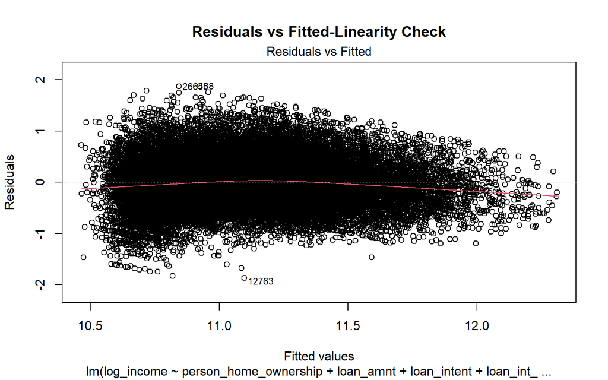

```r
plot(lm_step, which = 1, main = "Residuals vs Fitted-Linearity Check")
```

> A roughly **horizontal red line centered at zero** confirms linearity. Systematic curvature would indicate violation.

#### Assumption 2.Normality of Residuals

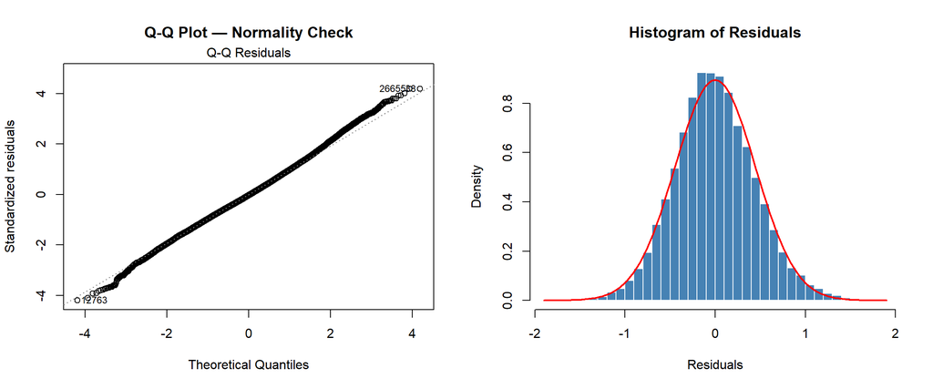

```r
par(mfrow = c(1, 2))
plot(lm_step, which = 2, main = "Q-Q Plot — Normality Check")
hist(residuals(lm_step), breaks = 50, col = "steelblue", border = "white",
     main = "Histogram of Residuals", xlab = "Residuals", probability = TRUE)
curve(dnorm(x, mean = mean(residuals(lm_step)), sd = sd(residuals(lm_step))),
      add = TRUE, col = "red", lwd = 2)
```

```r
par(mfrow = c(1, 1))
```

> Points closely following the diagonal in the Q-Q plot confirm approximate normality. The histogram overlay reinforces this.

#### Assumption 3.Homoscedasticity (Constant Variance)

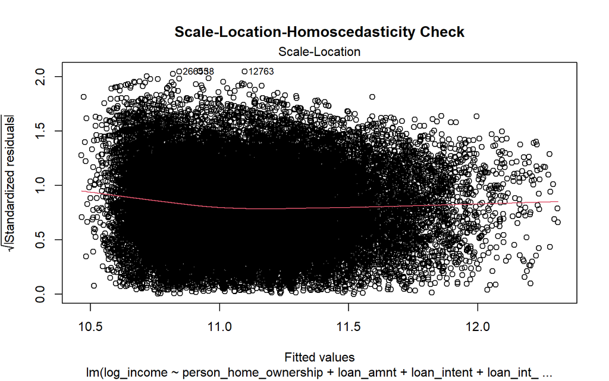

```r
plot(lm_step, which = 3, main = "Scale-Location-Homoscedasticity Check")
```

> A **roughly horizontal line with equally spread points** supports constant variance. A funnel shape would indicate heteroscedasticity.

#### Assumption 4.No Multicollinearity (VIF)

```r
vif_values <- vif(lm_step)
print(vif_values)
```

```
##                                    GVIF Df GVIF^(1/(2*Df))
## person_home_ownership          1.087615  3        1.014096
## loan_amnt                      1.057642  1        1.028417
## loan_intent                    1.041801  5        1.004104
## loan_int_rate                  1.076596  1        1.037592
## credit_score                   1.071971  1        1.035360
## previous_loan_defaults_on_file 1.096307  1        1.047047
## age_exp_ratio                  1.048521  1        1.023973
```

```r
cat("\nVariables with GVIF^(1/(2*Df)) > 2.5 (potential multicollinearity):\n")
```

```
##
## Variables with GVIF^(1/(2*Df)) > 2.5 (potential multicollinearity):
```

```r
gvif_adj <- vif_values[, "GVIF^(1/(2*Df))"]
high_vif <- gvif_adj[gvif_adj > 2.5]
if (length(high_vif) > 0) print(high_vif) else cat("None detected.\n")
```

```
## None detected.
```

> **Rule of thumb:** GVIF^(1/(2×Df)) > 2.5 suggests problematic multicollinearity.

#### Influence and Leverage (Cook’s Distance)

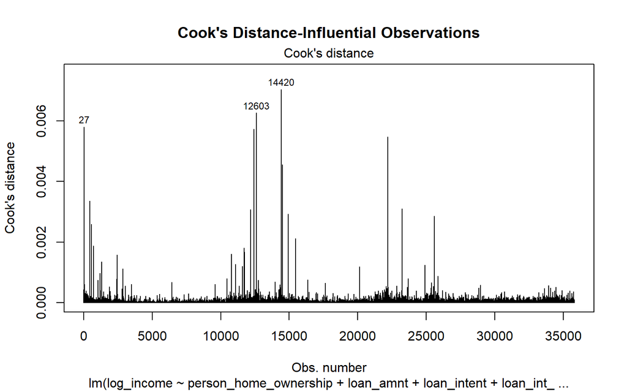

```r
plot(lm_step, which = 4, main = "Cook's Distance-Influential Observations")
```

```r
cooks_d      <- cooks.distance(lm_step)
influential  <- which(cooks_d > 4 / nrow(train_reg))
cat("Influential observations (Cook's D > 4/n):", length(influential), "\n")
```

```
## Influential observations (Cook's D > 4/n): 1706
```

### All Diagnostic Plots

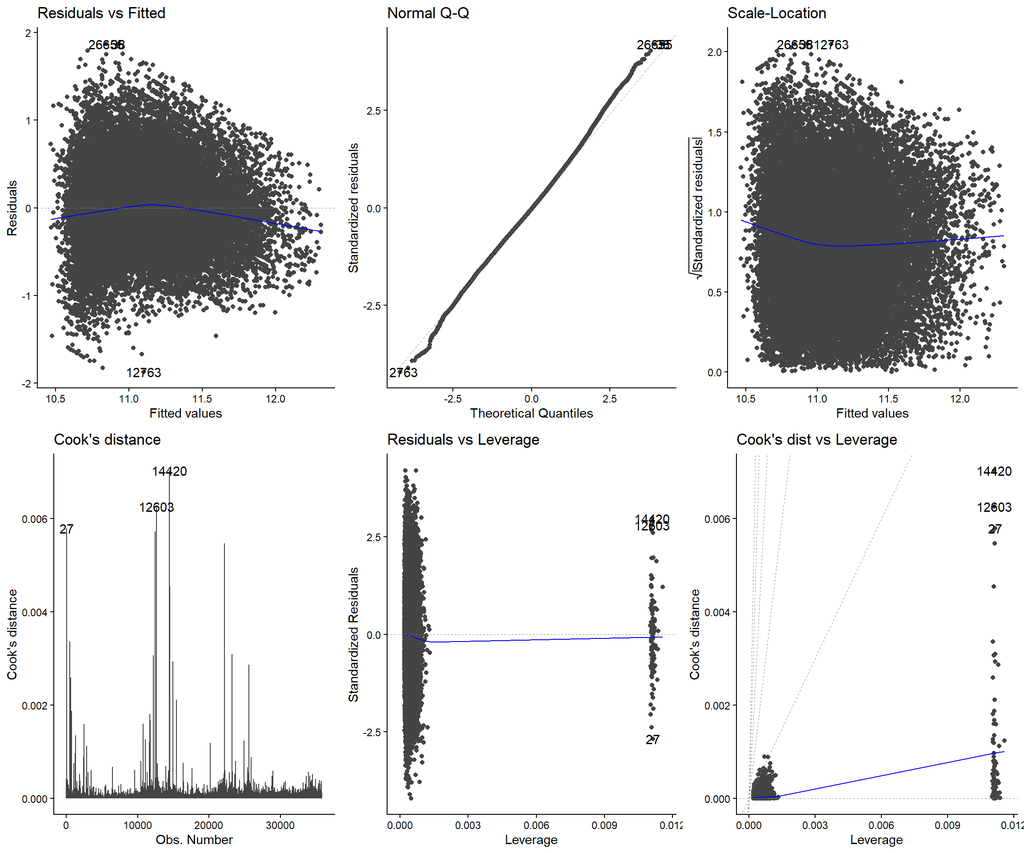

```r
autoplot(lm_step, which = 1:6, ncol = 3) + theme_classic()
```

### Comparing Transformations: Log vs Sqrt

```r
lm_sqrt <- lm(sqrt(person_income) ~ .-log_income,
              data = train_reg)

cat("Log Transform Adj R²:", round(summary(lm_step)$adj.r.squared, 4), "\n")
```

```
## Log Transform Adj R²: 0.3108
```

```r
cat("Sqrt Transform Adj R²:", round(summary(lm_sqrt)$adj.r.squared, 4), "\n")
```

```
## Sqrt Transform Adj R²: 0.2979
```

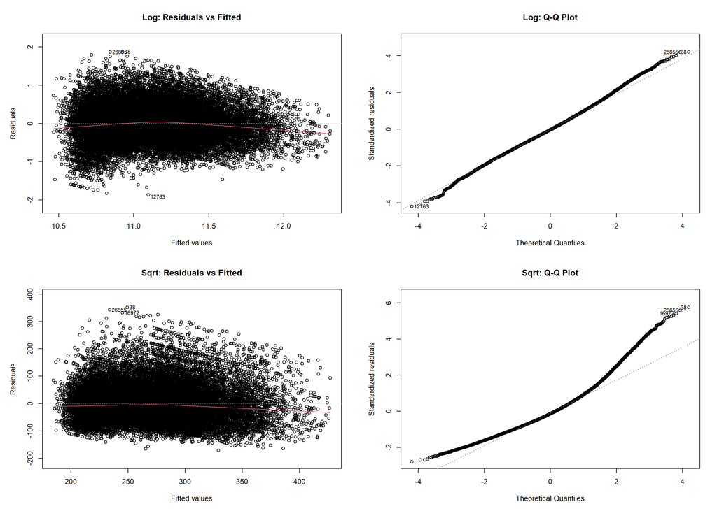

```r
par(mar = c(5, 5, 4, 2), mfrow = c(2, 2))
plot(lm_step, which = 1, main = "Log: Residuals vs Fitted", sub.caption = "", caption = "")
plot(lm_step, which = 2, main = "Log: Q-Q Plot", sub.caption = "", caption = "")
plot(lm_sqrt, which = 1, main = "Sqrt: Residuals vs Fitted", sub.caption = "", caption = "")
plot(lm_sqrt, which = 2, main = "Sqrt: Q-Q Plot", sub.caption = "", caption = "")
```

```r
par(mfrow = c(1, 1))
```

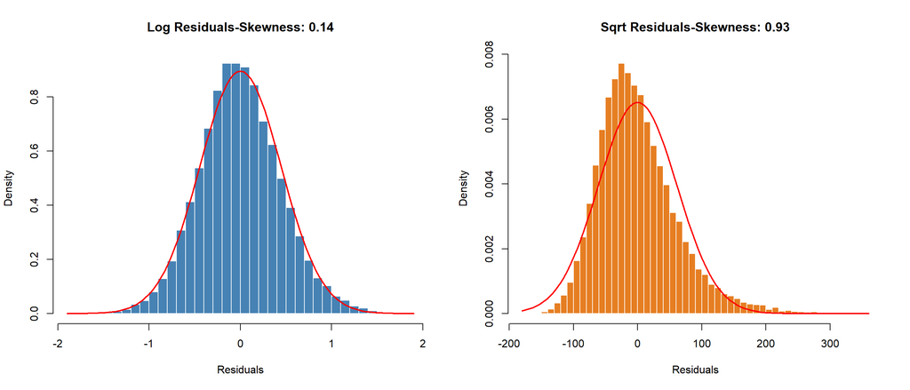

```r
par(mfrow = c(1, 2))
hist(residuals(lm_step), breaks = 50, col = "steelblue", border = "white",
     main = paste("Log Residuals-Skewness:", round(skewness(residuals(lm_step)), 3)),
     xlab = "Residuals", probability = TRUE)
curve(dnorm(x, mean(residuals(lm_step)), sd(residuals(lm_step))),
      add = TRUE, col = "red", lwd = 2)

hist(residuals(lm_sqrt), breaks = 50, col = "#e67e22", border = "white",
     main = paste("Sqrt Residuals-Skewness:", round(skewness(residuals(lm_sqrt)), 3)),
     xlab = "Residuals", probability = TRUE)
curve(dnorm(x, mean(residuals(lm_sqrt)), sd(residuals(lm_sqrt))),
      add = TRUE, col = "red", lwd = 2)
```

```r
par(mfrow = c(1, 1))
```

> **Conclusion:** The **log transformation** yields better normality, lower skewness in residuals and a higher Adjusted R² it remains the preferred transformation.

## Model 2.Decision Tree Regressor

```r
dt_model <- rpart(log_income ~.-person_income,
                  data = train_reg, method = "anova",
                  control = rpart.control(cp = 0.001, maxdepth = 10, minsplit = 20))

printcp(dt_model)
```

```
##
## Regression tree:
## rpart(formula = log_income ~ . - person_income, data = train_reg,
##     method = "anova", control = rpart.control(cp = 0.001, maxdepth = 10,
##         minsplit = 20))
##
## Variables actually used in tree construction:
## [1] age_exp_ratio                  loan_amnt
## [3] loan_intent                    person_home_ownership
## [5] previous_loan_defaults_on_file
##
## Root node error: 10322/35813 = 0.28823
##
## n= 35813
##
##           CP nsplit rel error  xerror      xstd
## 1  0.1444362      0   1.00000 1.00003 0.0079693
## 2  0.0703453      1   0.85556 0.85623 0.0069574
## 3  0.0268692      2   0.78522 0.78624 0.0062481
## 4  0.0150225      3   0.75835 0.76199 0.0060850
## 5  0.0136936      4   0.74333 0.74676 0.0060097
## 6  0.0096116      5   0.72963 0.73306 0.0058039
## 7  0.0059841      6   0.72002 0.71984 0.0057478
## 8  0.0059051      7   0.71404 0.71394 0.0056780
## 9  0.0057884      8   0.70813 0.71284 0.0056639
## 10 0.0051358      9   0.70234 0.70432 0.0055694
## 11 0.0030999     10   0.69721 0.70014 0.0055367
## 12 0.0029343     11   0.69411 0.69727 0.0055320
## 13 0.0026340     12   0.69117 0.69387 0.0055148
## 14 0.0019807     13   0.68854 0.69314 0.0055079
## 15 0.0017686     14   0.68656 0.69092 0.0054827
## 16 0.0014888     15   0.68479 0.68860 0.0054722
## 17 0.0014229     16   0.68330 0.68644 0.0054505
## 18 0.0011768     17   0.68188 0.68513 0.0054376
## 19 0.0011688     18   0.68070 0.68359 0.0054297
## 20 0.0011000     19   0.67953 0.68322 0.0054299
## 21 0.0010298     20   0.67843 0.68229 0.0054250
## 22 0.0010000     21   0.67740 0.68207 0.0054227
```

## Model 3.Random Forest Regressor

```r
set.seed(42)
rf_model <- randomForest(log_income ~ .-person_income,
                         data = train_reg,
                         ntree = 150,
                         mtry = 3,
                         nodesize = 20,
                         importance = TRUE)
print(rf_model)
```

```
##
## Call:
##  randomForest(formula = log_income ~ . - person_income, data = train_reg,      ntree = 150, mtry = 3, nodesize = 20, importance = TRUE)
##                Type of random forest: regression
##                      Number of trees: 150
## No. of variables tried at each split: 3
##
##           Mean of squared residuals: 0.1902029
##                     % Var explained: 34.01
```

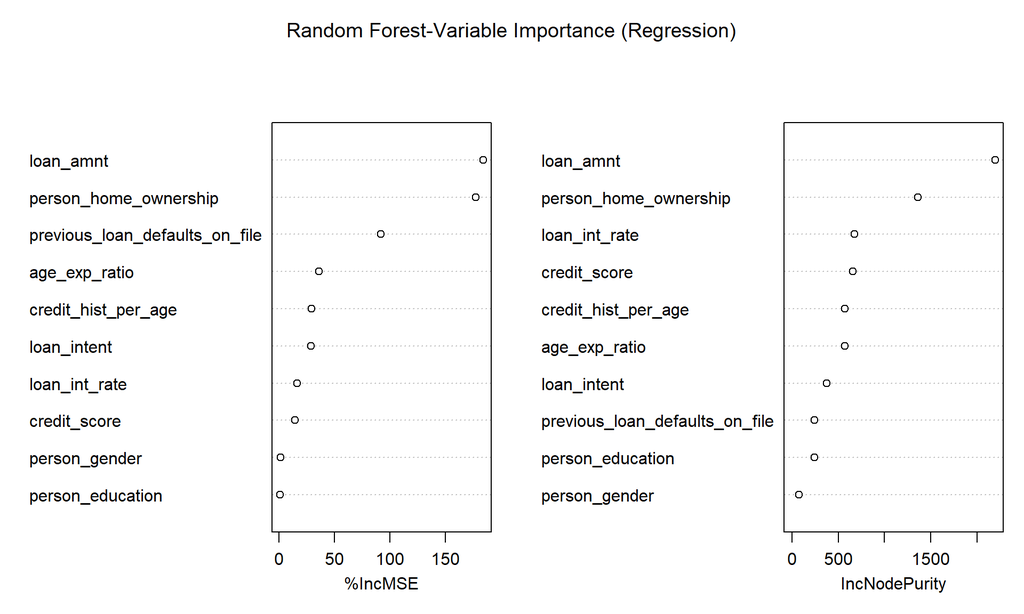

```r
varImpPlot(rf_model, main = "Random Forest-Variable Importance (Regression)")
```

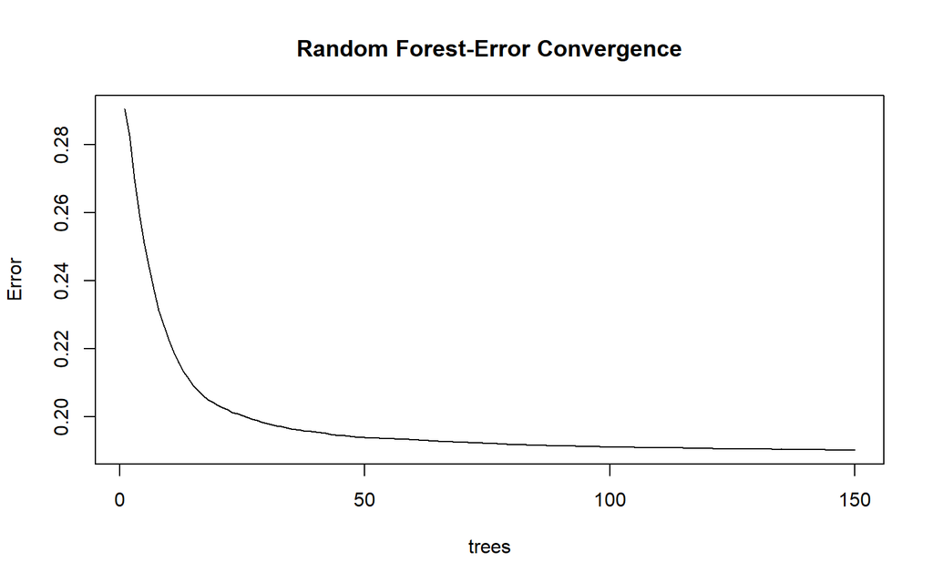

```r
plot(rf_model, main = "Random Forest-Error Convergence")
```

**The model has converged.** Adding more trees past 150 isn’t improving performance the error is flat. The forest has extracted all the signal it can from these predictors.

## Regression Model Comparison

```r
pred_lm <- exp(predict(lm_step, newdata = test_reg))
pred_dt <- predict(dt_model, newdata = test_reg)
pred_rf <- predict(rf_model, newdata = test_reg)
actual  <- test_reg$person_income
```

```r
calc_metrics <- function(actual, predicted, model_name) {
  data.frame(
    Model     = model_name,
    RMSE      = round(rmse(actual, predicted), 2),
    MAE       = round(mae(actual, predicted), 2),
    R_Squared = round(1 - sum((actual - predicted)^2) / sum((actual - mean(actual))^2), 4),
    MAPE      = round(mean(abs((actual - predicted) / actual)) * 100, 2)
  )
}

comparison_reg <- rbind(
  calc_metrics(actual, pred_lm, "Linear Regression (log):"),
  calc_metrics(actual, pred_dt, "Decision Tree:"),
  calc_metrics(actual, pred_rf, "Random Forest:")
)

print(comparison_reg)
```

```
##                      Model     RMSE      MAE R_Squared  MAPE
## 1 Linear Regression (log): 37645.02 25698.96    0.2509 36.78
## 2           Decision Tree: 88360.74 76915.27   -3.1274 99.98
## 3           Random Forest: 88360.73 76915.26   -3.1274 99.98
```

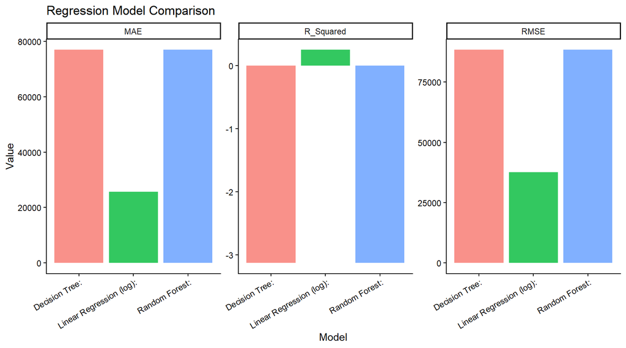

```r
comparison_long <- comparison_reg %>%
  pivot_longer(cols = c(RMSE, MAE, R_Squared), names_to = "Metric", values_to = "Value")

ggplot(comparison_long, aes(x = Model, y = Value, fill = Model)) +
  geom_col(alpha = 0.8) +
  facet_wrap(~Metric, scales = "free_y") +
  labs(title = "Regression Model Comparison", y = "Value") +
  theme(axis.text.x = element_text(angle = 30, hjust = 1), legend.position = "none")
```

### Best Regression Model

```r
best_model_table <- data.frame(
  Metric = c("Model", "RMSE", "MAE", "R²", "MAPE (%)"),
  Value  = c("Linear Regression (log)", "37,645", "25,698", "0.2509", "36.78")
)

knitr::kable(best_model_table,
             caption = "Best Regression Model: Linear Regression (log)",
             align = c("l", "r"))
```

Best Regression Model: Linear Regression (log)

| Metric | Value |
| --- | --- |
| Model | Linear Regression (log) |
| RMSE | 37,645 |
| MAE | 25,698 |
| R² | 0.2509 |
| MAPE (%) | 36.78 |

**Linear Regression(Log)** as the best model because it had the highest R squared (0.2509).

# Part B.Classification: Loan Default Prediction

## Objective

Predict whether a loan applicant will **default** (`loan_status = 0`) or **repay** (`loan_status = 1`) using all available features, including engineered ones.

## Prepare Classification Data

```r
clf_df <- df %>%
  dplyr::select(loan_status, person_age, person_gender, person_education, person_income,
                person_emp_exp, person_home_ownership, loan_amnt, loan_intent,
                loan_int_rate, loan_percent_income, cb_person_cred_hist_length,
                credit_score, previous_loan_defaults_on_file,
                loan_credit_ratio, age_exp_ratio, high_risk) %>%
  drop_na()

clf_df$person_education <- factor(clf_df$person_education, ordered = FALSE)

cat("Classification dataset:", nrow(clf_df), "rows x", ncol(clf_df), "columns\n")
```

```
## Classification dataset: 44765 rows x 17 columns
```

## TrainTest Split

```r
set.seed(42)
train_idx_clf <- createDataPartition(clf_df$loan_status, p = 0.8, list = FALSE)
train_clf     <- clf_df[train_idx_clf, ]
test_clf      <- clf_df[-train_idx_clf, ]

cat("Training:", nrow(train_clf), "| Test:", nrow(test_clf), "\n")
```

```
## Training: 35813 | Test: 8952
```

## Model 1.Logistic Regression

Logistic regression is the natural extension of linear regression for binary outcomes and serves as our baseline classifier.

```r
log_model <- glm(loan_status ~ ., data = train_clf, family = binomial(link = "logit"))
log_step  <- stepAIC(log_model, direction = "both", trace = FALSE)

prob_log  <- predict(log_step, newdata = test_clf, type = "response")
pred_log  <- factor(ifelse(prob_log > 0.5, 1, 0), levels = c("0", "1"))

cat("\n Logistic Regression \n")
```

```
##
##  Logistic Regression
```

```r
cm_log <- confusionMatrix(pred_log, test_clf$loan_status, positive = "1")
print(cm_log)
```

```
## Confusion Matrix and Statistics
##
##           Reference
## Prediction    0    1
##          0 6532  508
##          1  425 1487
##
##                Accuracy : 0.8958
##                  95% CI : (0.8893, 0.902)
##     No Information Rate : 0.7771
##     P-Value [Acc > NIR] : < 2.2e-16
##
##                   Kappa : 0.6946
##
##  Mcnemar's Test P-Value : 0.007263
##
##             Sensitivity : 0.7454
##             Specificity : 0.9389
##          Pos Pred Value : 0.7777
##          Neg Pred Value : 0.9278
##              Prevalence : 0.2229
##          Detection Rate : 0.1661
##    Detection Prevalence : 0.2136
##       Balanced Accuracy : 0.8421
##
##        'Positive' Class : 1
##
```

**Accuracy: 0.8958 (89.58%)**:The model correctly classifies about 9 out of every 10 loans. This sounds great, but with class imbalance you have to compare it to the baseline.

**P-Value [Acc > NIR]: < 2.2e-16** :The model’s accuracy means it’s actually learning something, not just exploiting the imbalance.

**Sensitivity (Recall): 0.7454**:Of all the people who *actually* repaid their loans, the model correctly identified **74.5%** of them. The remaining 25.5% (the 508 false negatives) were wrongly flagged as defaulters.

## Model 2.Decision Tree Classifier

```r
dt_clf <- rpart(loan_status ~ ., data = train_clf, method = "class",
                control = rpart.control(cp = 0.001, maxdepth = 8))

pred_dt_clf <- predict(dt_clf, newdata = test_clf, type = "class")
prob_dt_clf <- predict(dt_clf, newdata = test_clf, type = "prob")[, 2]

cat("\n Decision Tree \n")
```

```
##
##  Decision Tree
```

```r
cm_dt <- confusionMatrix(pred_dt_clf, test_clf$loan_status, positive = "1")
print(cm_dt)
```

```
## Confusion Matrix and Statistics
##
##           Reference
## Prediction    0    1
##          0 6755  515
##          1  202 1480
##
##                Accuracy : 0.9199
##                  95% CI : (0.9141, 0.9254)
##     No Information Rate : 0.7771
##     P-Value [Acc > NIR] : < 2.2e-16
##
##                   Kappa : 0.7551
##
##  Mcnemar's Test P-Value : < 2.2e-16
##
##             Sensitivity : 0.7419
##             Specificity : 0.9710
##          Pos Pred Value : 0.8799
##          Neg Pred Value : 0.9292
##              Prevalence : 0.2229
##          Detection Rate : 0.1653
##    Detection Prevalence : 0.1879
##       Balanced Accuracy : 0.8564
##
##        'Positive' Class : 1
##
```

Out of 8,952 test observations, the Decision Tree got **8,235 correct** and **717 wrong** that’s **216 fewer errors** than Logistic Regression (which had 933 wrong).

Accuracy: 0.9199 (91.99%):A clear improvement over Logistic Regression’s 89.58%

P-Value [Acc > NIR]: < 2.2e-16:Statistically significantly better than guessing the majority class.

Sensitivity (Recall): 0.7419 Of all the people who actually repaid, the model correctly identified 74.2% of them.

## Model 3.Random Forest Classifier

```r
set.seed(42)
rf_clf <- randomForest(loan_status ~ ., data = train_clf,
                       ntree = 500, mtry = 4, importance = TRUE)

pred_rf_clf <- predict(rf_clf, newdata = test_clf)
prob_rf_clf <- predict(rf_clf, newdata = test_clf, type = "prob")[, 2]

cat("\n Random Forest \n")
```

```
##
##  Random Forest
```

```r
cm_rf <- confusionMatrix(pred_rf_clf, test_clf$loan_status, positive = "1")
print(cm_rf)
```

```
## Confusion Matrix and Statistics
##
##           Reference
## Prediction    0    1
##          0 6763  463
##          1  194 1532
##
##                Accuracy : 0.9266
##                  95% CI : (0.921, 0.9319)
##     No Information Rate : 0.7771
##     P-Value [Acc > NIR] : < 2.2e-16
##
##                   Kappa : 0.7774
##
##  Mcnemar's Test P-Value : < 2.2e-16
##
##             Sensitivity : 0.7679
##             Specificity : 0.9721
##          Pos Pred Value : 0.8876
##          Neg Pred Value : 0.9359
##              Prevalence : 0.2229
##          Detection Rate : 0.1711
##    Detection Prevalence : 0.1928
##       Balanced Accuracy : 0.8700
##
##        'Positive' Class : 1
##
```

Out of 8,952 test observations, the Random Forest got **8,295 correct** and only **657 wrong** — the fewest errors of any model so far.  
**Sensitivity (Recall): 0.7679** — The Random Forest correctly identifies **76.8%** of actual repayers.

### ROC Curves & AUC Comparison

**Why AUC over Accuracy?** With 78 % defaults, a naive “always predict default” model achieves 78 % accuracy but is useless. AUC measures how well the model **separates** the two classes regardless of proportion.

**ROC** stands for **Receiver Operating Characteristic**. It’s a curve that plots two things as you change the classification threshold (the 0.5 cutoff).  
**AUC** stands for **Area Under the Curve**. It’s a single number that summarizes the entire ROC curve:

- **AUC = 1.0** perfect model, never makes mistakes
- **AUC = 0.9–1.0** excellent model
- **AUC = 0.8–0.9** good model

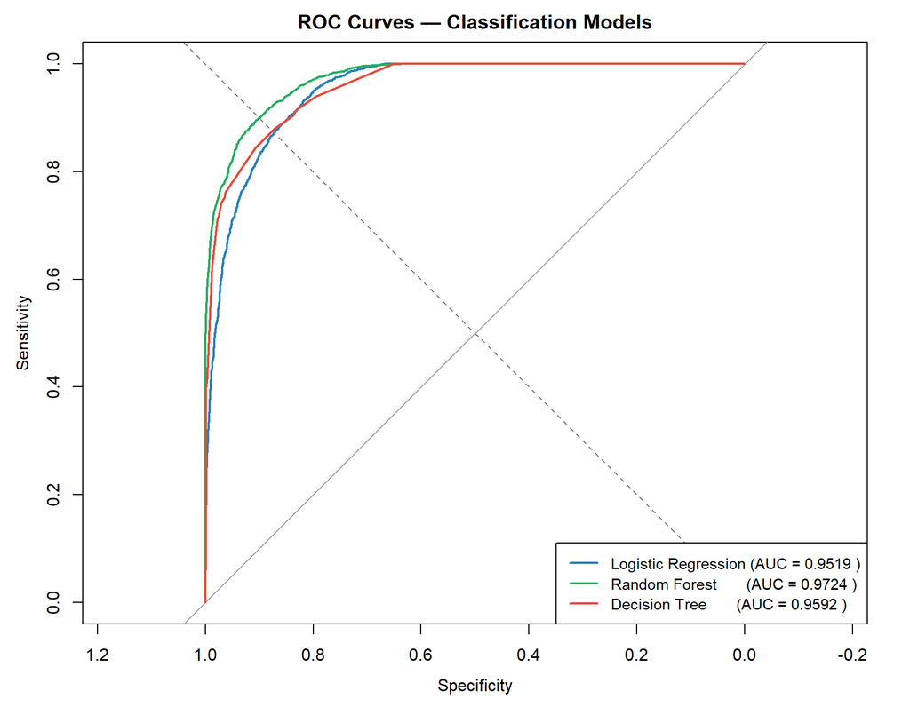

```r
roc_log <- roc(test_clf$loan_status, prob_log, levels = c("0", "1"), direction = "<")
roc_rf  <- roc(test_clf$loan_status, prob_rf_clf, levels = c("0", "1"), direction = "<")
roc_dt  <- roc(test_clf$loan_status, prob_dt_clf, levels = c("0", "1"), direction = "<")

plot(roc_log, col = "#2980b9", lwd = 2, main = "ROC Curves — Classification Models")
plot(roc_rf, col = "#27ae60", lwd = 2, add = TRUE)
plot(roc_dt, col = "#e74c3c", lwd = 2, add = TRUE)
abline(a = 0, b = 1, lty = 2, col = "gray50")

legend("bottomright",
       legend = c(
         paste("Logistic Regression (AUC =", round(auc(roc_log), 4), ")"),
         paste("Random Forest       (AUC =", round(auc(roc_rf), 4), ")"),
         paste("Decision Tree       (AUC =", round(auc(roc_dt), 4), ")")
       ),
       col = c("#2980b9", "#27ae60", "#e74c3c"), lwd = 2, cex = 0.9)
```

## Classification Summary Table

```r
clf_comparison <- data.frame(
  Model       = c("Logistic Regression", "Random Forest", "Decision Tree"),
  Accuracy    = c(cm_log$overall["Accuracy"], cm_rf$overall["Accuracy"],
                  cm_dt$overall["Accuracy"]),
  Sensitivity = c(cm_log$byClass["Sensitivity"], cm_rf$byClass["Sensitivity"],
                  cm_dt$byClass["Sensitivity"]),
  Specificity = c(cm_log$byClass["Specificity"], cm_rf$byClass["Specificity"],
                  cm_dt$byClass["Specificity"]),
  F1_Score    = c(cm_log$byClass["F1"], cm_rf$byClass["F1"], cm_dt$byClass["F1"]),
  AUC         = c(auc(roc_log), auc(roc_rf), auc(roc_dt))
) %>%
  mutate(across(where(is.numeric), ~ round(., 4)))

print(clf_comparison)
```

```
##                 Model Accuracy Sensitivity Specificity F1_Score    AUC
## 1 Logistic Regression   0.8958      0.7454      0.9389   0.7612 0.9519
## 2       Random Forest   0.9266      0.7679      0.9721   0.8234 0.9724
## 3       Decision Tree   0.9199      0.7419      0.9710   0.8050 0.9592
```

**All three models have AUC > 0.95** have exceptionally strong discrimination. Any of them can reliably *rank* borrowers by default risk.  
**Specificity (97%) is much higher than Sensitivity (75%) across the board** This reflects the 78/22 class imbalance and is actually appropriate for lending risk management.  
**Random Forest’s edge over Decision Tree is small** (0.0067 in accuracy, 0.0132 in AUC.

**Logistic Regression’s competitive AUC validates it as a strong baseline.**

### Best Classification Model

```r
best_clf_idx <- which.max(clf_comparison$AUC)
cat("═══════════════════════════════════════\n")
```

```
## ═══════════════════════════════════════
```

```r
cat("  BEST CLASSIFICATION MODEL\n")
```

```
##   BEST CLASSIFICATION MODEL
```

```r
cat("═══════════════════════════════════════\n")
```

```
## ═══════════════════════════════════════
```

```r
cat("  Model   :", clf_comparison$Model[best_clf_idx], "\n")
```

```
##   Model   : Random Forest
```

```r
cat("  AUC     :", clf_comparison$AUC[best_clf_idx], "\n")
```

```
##   AUC     : 0.9724
```

```r
cat("  Accuracy:", clf_comparison$Accuracy[best_clf_idx], "\n")
```

```
##   Accuracy: 0.9266
```

```r
cat("  F1 Score:", clf_comparison$F1_Score[best_clf_idx], "\n")
```

```
##   F1 Score: 0.8234
```

# Credit Risk Analysis

This section synthesizes findings on how **income**, **credit score** and **prior defaults** interact to drive loan outcomes.

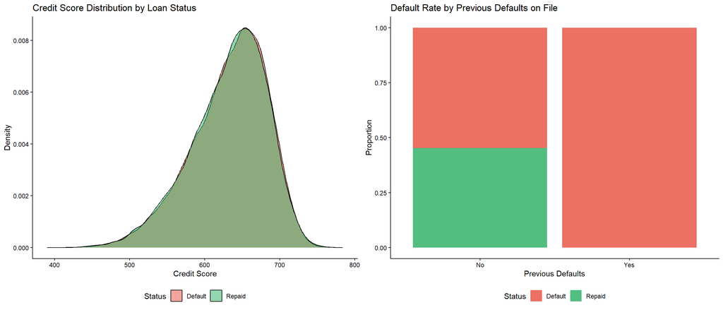

```r
p_cr1 <- ggplot(df, aes(x = credit_score, fill = loan_status)) +
  geom_density(alpha = 0.5) +
  scale_fill_manual(values = c("#e74c3c", "#27ae60"), labels = c("Default", "Repaid")) +
  labs(title = "Credit Score Distribution by Loan Status",
       x = "Credit Score", y = "Density", fill = "Status") +
  theme(legend.position = "bottom")

p_cr2 <- ggplot(df, aes(x = previous_loan_defaults_on_file, fill = loan_status)) +
  geom_bar(position = "fill", alpha = 0.8) +
  scale_fill_manual(values = c("#e74c3c", "#27ae60"), labels = c("Default", "Repaid")) +
  labs(title = "Default Rate by Previous Defaults on File",
       x = "Previous Defaults", y = "Proportion", fill = "Status") +
  theme(legend.position = "bottom")

grid.arrange(p_cr1, p_cr2, ncol = 2)
```

Left Plot :Credit Score Distribution by Loan Status  
This visually confirms what the correlation matrix showed: **credit score alone is a very weak predictor of default in this dataset**. If credit score were strongly predictive, you’d expect to see two clearly separated curves defaulters skewed left, repayers skewed right.  
**Applicants with NO previous defaults**:about **55% default, 45% repaid**. Defaults are still the majority, but almost half successfully repay.  
**Applicants WITH previous defaults (“Yes”)** :**100% default, 0% repaid**. The green slice is completely absent.  
So having a previous default on file is essentially a **perfect predictor of future default** ,*every single one* of those applicants defaulted again. Making this one of the strongest single-variable signals in this data set dataset.